# KNN

Tomás Sánchez Grigioni

# Bibliotecas

```r
library(tidyverse)
library(caret)
library(pROC)

source("../R/Utils.R")
```

# Constantes y otros

```r
# ARCHIVOS
PATH_DATOS_IN <- "../data/bd_final_refactor.csv"

FILE_COLUMN_SEPARATOR <- ";"
FILE_DECIMAL_SEPARATOR <- "."

# CARET

# División datos
SEED <- 12345
PORCENTAJE_TRAIN <- 0.7

# Pre-procesamiento
PRE_PROCESS_NORMALIZAR <- "range"
PRE_PROCESS_ESTANDARIZAR <- c("center", "scale")

# Grid
K_MIN <- 3
K_MAX <- 25
AVANCE_k <- 1

# Train control
METODO_CROSS_VALIDATION <- "cv"
K_FOLD <- 10

# Train
METODO_KNN <- "knn"

# CURVA ROC
NOMBRE_NIVEL_POSITIVO_VAR_RESPUESTA <-  "true"
NOMBRE_VAR_RESPUESTA <-  "diagnostico_pro"
TYPE_PREDICT_KNN <-  "prob"

# GENERAL
ESPACIO_BlANCO <- " "
```

# Cargar datos

```r
datos_crudos <- read.table(PATH_DATOS_IN, header = TRUE, sep = FILE_COLUMN_SEPARATOR, dec = FILE_DECIMAL_SEPARATOR)
```

# Manipulación de datos

```r
glimpse(datos_crudos)
```

Solo hacemos que las variables que aparecen como pasen a ser factores

```r
datos <- datos_crudos %>%
  map_dfr(~ if(is.character(.x)) { as.factor(.x) } else { .x })

glimpse(datos)
```

# Aplicar algoritmo KNN

## Ejemplo sencillo

Para hacer algo sencillo, solo usamos dos variables numéricas individuales

```r
vars_knn_sencillo <- c("diagnostico_pro", "d1", "d2")
```

Creamos un nuevo df con las variables elegidas

```r
df_knn_sencillo <- datos %>% select(all_of(vars_knn_sencillo))
glimpse(df_knn_sencillo)
```

Hacemos un pequeño grafico de d1 vs d2 mostrando a que clase de diagnostico_pro pertenece

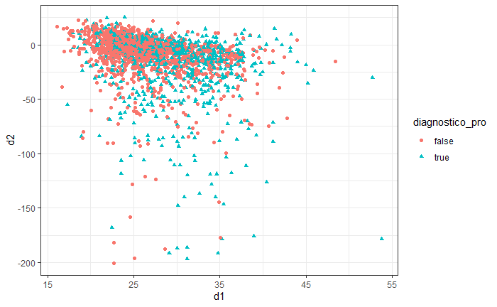

```r
ggplot(df_knn_sencillo, aes(d1, d2, color = diagnostico_pro, shape = diagnostico_pro)) +
  geom_point() +
  theme_bw()
```

Observamos que se solapan bastante estos datos, pero igual vamos a aplicar el algoritmo para hacer el ejemplo.

Vamos a normalizar los datos

```r
df_knn_sencillo_split <- df_knn_sencillo %>%
  preProcess(method = PRE_PROCESS_NORMALIZAR) %>%
  predict(df_knn_sencillo) %>%
  data.frame()

# Verificamos que se haya realizado correctamente
df_knn_sencillo_split %>%
  select(where(is.numeric)) %>%
  summary()
```

```
       d1               d2
 Min.   :0.0000   Min.   :0.0000
 1st Qu.:0.2073   1st Qu.:0.8140
 Median :0.2774   Median :0.8623
 Mean   :0.3053   Mean   :0.8330
 3rd Qu.:0.3943   3rd Qu.:0.8949
 Max.   :1.0000   Max.   :1.0000
```

Dividimos los datos

```r
# Particionar datos
set.seed(SEED)

indices_train <- createDataPartition(df_knn_sencillo_split$diagnostico_pro, p = PORCENTAJE_TRAIN, list = FALSE) %>% as.vector()

df_knn_sencillo_train <- df_knn_sencillo_split[indices_train,]
df_knn_sencillo_test <- df_knn_sencillo_split[-indices_train,]

nrow(df_knn_sencillo_test)
```

```
[1] 665
```

```r
nrow(df_knn_sencillo_train)
```

```
[1] 1553
```

En este algoritmo hay que definir un valor de k. Para esto lo que vamos a usar es el método de 10-fold cross-validation.

```r
# Definimos todos los valores de k a probar.
# Observamos como se debe llamar el parámetro según el modelo que voy a usar, para nuestro caso "knn".
#getModelInfo(model = "knn")

grid <- expand.grid(k = seq(K_MIN, K_MAX))
grid
```

| k |
| --- |
| 3 |
| 4 |
| 5 |
| 6 |
| 7 |
| 8 |
| 9 |
| 10 |
| 11 |
| 12 |

[output cut: 13 more lines]

Ahora, tenemos que especificar la forma de que vamos a obtener el valor de k óptimo.

```r
train_control <- trainControl(method = METODO_CROSS_VALIDATION, number = K_FOLD)
```

Ajustamos el algoritmo a los datos

```r
set.seed(SEED)

knn_sencillo <- train(diagnostico_pro ~ .,
                      data = df_knn_sencillo_train,
                      method = METODO_KNN,
                      tuneGrid = grid,
                      trControl = train_control)
knn_sencillo
```

```
k-Nearest Neighbors

1553 samples
   2 predictor
   2 classes: 'false', 'true'

No pre-processing
Resampling: Cross-Validated (10 fold)
Summary of sample sizes: 1397, 1397, 1397, 1398, 1397, 1397, ...
Resampling results across tuning parameters:

  k   Accuracy   Kappa
   3  0.5788265  0.1282648
   4  0.5853322  0.1442248
   5  0.5885041  0.1499503
   6  0.5847120  0.1387708
   7  0.5969165  0.1647142
   8  0.5859900  0.1370816
   9  0.5917798  0.1492805
  10  0.5950057  0.1533233
  11  0.6123634  0.1904345
  12  0.6110314  0.1853322
  13  0.6033183  0.1698266
  14  0.6072061  0.1799273
  15  0.5994638  0.1621693
  16  0.6007501  0.1658075
  17  0.6020322  0.1683827
  18  0.5975530  0.1576183
  19  0.6013912  0.1677547
  20  0.5981860  0.1603401
  21  0.6033432  0.1726219
  22  0.6077929  0.1804289
  23  0.5968789  0.1581516
  24  0.6014117  0.1655624
  25  0.6058989  0.1760074

Accuracy was used to select the optimal model using the largest value.
The final value used for the model was k = 11.
```

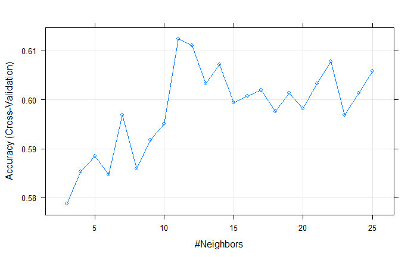

```r
# Este paquete también nos permite graficar como varía la métrica usada para elegir el valor de k óptimo
plot(knn_sencillo)
```

Por último vemos como perfoma el modelo con el test

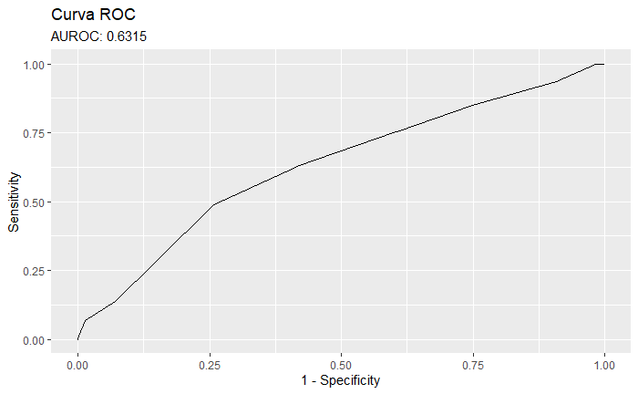

```r
graficar_curva_roc(knn_sencillo,
                   df_knn_sencillo_test,
                   nivel_positivo = NOMBRE_NIVEL_POSITIVO_VAR_RESPUESTA,
                   var_respuesta = NOMBRE_VAR_RESPUESTA,
                   type_predict = TYPE_PREDICT_KNN)
```

## Ejemplo Más Complejo

```r
vars_knn_complejo <- c("diagnostico_pro", "d1", "d2", "d3", "d4", "d5", "edad", "educ", "empleo", "genero")
df_knn_complejo <- datos %>% select(all_of(vars_knn_complejo)) %>% drop_na()
glimpse(df_knn_complejo)
```

Primero vamos a hacer un preprocesamiento de los datos. Basicamente serán dos tareas:

- Normalizar los datos: (x - xmin) / (xmax - xmin).
- Crear dummy variables para todas las categóricas, excepto la daignostico_pro.

Comenzamos con la normaliación.

```r
# Separamos, para que todo lo que hagamos no afecte a la var respuesta
df_x <- df_knn_complejo[,1]
df_y <- df_knn_complejo[,-1]

# Normalizamos los datos, esta función ignora a las factores así que en realidad no pasa nada por tener todas las predictoras juntas.
df_y_normalizado <- df_y %>%
  preProcess(method = PRE_PROCESS_NORMALIZAR) %>%
  predict(df_y) %>%
  data.frame()

# Verificamos que se haya realizado correctamente, ahora todos los xmin y xmax son 0 y 1 respectivamente
df_y_normalizado %>%
  select(where(is.numeric)) %>%
  summary()
```

```
       d1               d2               d3               d4               d5               edad
 Min.   :0.0000   Min.   :0.0000   Min.   :0.0000   Min.   :0.0000   Min.   :0.00000   Min.   :0.0000
 1st Qu.:0.2072   1st Qu.:0.8146   1st Qu.:0.1518   1st Qu.:0.4609   1st Qu.:0.02674   1st Qu.:0.1455
 Median :0.2775   Median :0.8623   Median :0.2896   Median :0.5500   Median :0.05190   Median :0.3273
 Mean   :0.3054   Mean   :0.8333   Mean   :0.3111   Mean   :0.5469   Mean   :0.09756   Mean   :0.3382
 3rd Qu.:0.3944   3rd Qu.:0.8949   3rd Qu.:0.4540   3rd Qu.:0.6349   3rd Qu.:0.11677   3rd Qu.:0.5091
 Max.   :1.0000   Max.   :1.0000   Max.   :1.0000   Max.   :1.0000   Max.   :1.00000   Max.   :1.0000
```

Creamos las variables dummy

```r
# Creación variables dummy
df_y_normalizado_dummy <- dummyVars(~., df_y_normalizado) %>%
  predict(df_y_normalizado) %>%
  data.frame()

# Una vez hecho esto podemos vovler a juntar los datos
df_knn_complejo_split <- cbind(df_x, df_y_normalizado_dummy)
```

Separamos los datos

```r
set.seed(SEED)
indices_train <- createDataPartition(df_knn_complejo_split$diagnostico_pro, p = PORCENTAJE_TRAIN)[[1]]

df_knn_complejo_train <- df_knn_complejo_split[indices_train,]
df_knn_complejo_test <- df_knn_complejo_split[-indices_train,]

# Verificamos
nrow(df_knn_complejo_split) == nrow(df_knn_complejo_test) + nrow(df_knn_complejo_train)
```

```
[1] TRUE
```

```r
# Grilla con los valores de k
grid_train <- expand.grid(k = seq(K_MIN, K_MAX))

# Control de entrenamineto
trian_control <- trainControl(method = METODO_CROSS_VALIDATION, number = K_FOLD)
```

Entrenamos el modelo

```r
knn_complejo <- train(diagnostico_pro ~ .,
                      df_knn_complejo_train,
                      method = METODO_KNN,
                      tuneGrid = grid_train)

knn_complejo
```

```
k-Nearest Neighbors

1543 samples
  14 predictor
   2 classes: 'false', 'true'

No pre-processing
Resampling: Bootstrapped (25 reps)
Summary of sample sizes: 1543, 1543, 1543, 1543, 1543, 1543, ...
Resampling results across tuning parameters:

  k   Accuracy   Kappa
   3  0.6754646  0.3340468
   4  0.6832347  0.3500209
   5  0.6912891  0.3667512
   6  0.6964154  0.3776083
   7  0.7019163  0.3890529
   8  0.7090861  0.4031656
   9  0.7128071  0.4102775
  10  0.7170794  0.4192643
  11  0.7220224  0.4285391
  12  0.7245508  0.4342406
  13  0.7267996  0.4390478
  14  0.7258677  0.4367142
  15  0.7275959  0.4400608
  16  0.7314549  0.4480303
  17  0.7322802  0.4497408
  18  0.7328453  0.4513611
  19  0.7348580  0.4553308
  20  0.7366634  0.4590615
  21  0.7378359  0.4607941
  22  0.7370408  0.4588074
  23  0.7391983  0.4634067
  24  0.7401899  0.4654335
  25  0.7394910  0.4639036

Accuracy was used to select the optimal model using the largest value.
The final value used for the model was k = 24.
```

Solo porque podemos, vemos el gráfico de cómo elige el Kmax

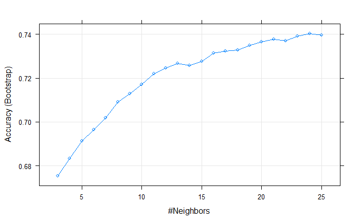

```r
plot(knn_complejo)
```

Observamos como es el AUROC

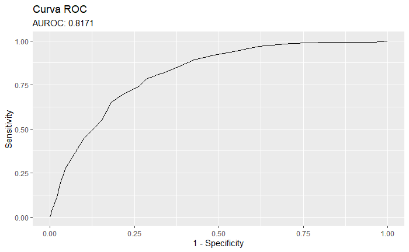

```r
graficar_curva_roc(knn_complejo,
                   df_knn_complejo_test,
                   nivel_positivo = NOMBRE_NIVEL_POSITIVO_VAR_RESPUESTA,
                   var_respuesta = NOMBRE_VAR_RESPUESTA,
                   type_predict = TYPE_PREDICT_KNN)
```

## Ejemplo Avanzando de A Poco

Vamos a probar como cambia el modelo a medida que agregamos más variables. Por cada submodelo lo que hacemos es:

- Normalizar variables numéricas.
- Crear variables dummy para categóricas.
- Dividir los datos.
- Entrenar un nuevo modelo.
- Calcular el AUROC.

Siempre vamos a usar la misma forma de seleccionar el mismo caso así que defenimos un train_control y una grid para todos los casos.

```r
train_control <- trainControl(method = METODO_CROSS_VALIDATION,  number = K_FOLD)
grid <- expand.grid(k = seq(K_MIN, K_MAX, AVANCE_k))
```

Las variables que vamos a usar son

```r
var_predictoras <- c("d1",
                     "d2",
                     "d3",
                     "d4",
                     "d5",
                     "edad",
                     "educ",
                     "empleo",
                     "genero",
                     "estado_marital",
                     "facilidad_celular",
                     "F0semitoneFrom27.5Hz_sma3nz_stddevNorm",
                     "F0semitoneFrom27.5Hz_sma3nz_amean",
                     "F0semitoneFrom27.5Hz_sma3nz_percentile20.0",
                     "F0semitoneFrom27.5Hz_sma3nz_percentile50.0",
                     "F0semitoneFrom27.5Hz_sma3nz_percentile80.0",
                     "F0semitoneFrom27.5Hz_sma3nz_stddevRisingSlope",
                     "F0semitoneFrom27.5Hz_sma3nz_meanFallingSlope",
                     "F0semitoneFrom27.5Hz_sma3nz_stddevFallingSlope",
                     "jitterLocal_sma3nz_amean",
                     "jitterLocal_sma3nz_stddevNorm",
                     "shimmerLocaldB_sma3nz_amean",
                     "shimmerLocaldB_sma3nz_stddevNorm")

# Verificamos que no tengan muchos nulos
datos[,var_predictoras] %>%
  map_int(~ sum(is.na(.x)))
```

```
                                            d1                                             d2                                             d3
                                             0                                              0                                              0
                                            d4                                             d5                                           edad
                                             0                                              0                                              0
                                          educ                                         empleo                                         genero
                                             7                                              8                                              2
                                estado_marital                              facilidad_celular         F0semitoneFrom27.5Hz_sma3nz_stddevNorm
                                             4                                              1                                              0
             F0semitoneFrom27.5Hz_sma3nz_amean     F0semitoneFrom27.5Hz_sma3nz_percentile20.0     F0semitoneFrom27.5Hz_sma3nz_percentile50.0
                                             0                                              0                                              0
    F0semitoneFrom27.5Hz_sma3nz_percentile80.0  F0semitoneFrom27.5Hz_sma3nz_stddevRisingSlope   F0semitoneFrom27.5Hz_sma3nz_meanFallingSlope
                                             0                                              0                                              0
F0semitoneFrom27.5Hz_sma3nz_stddevFallingSlope                       jitterLocal_sma3nz_amean                  jitterLocal_sma3nz_stddevNorm
                                             0                                              0                                              0
                   shimmerLocaldB_sma3nz_amean               shimmerLocaldB_sma3nz_stddevNorm
                                             0                                              0
```

```r
# Preparamos el df con los resutlados
df_resumen_resultados <- data.frame()

# Tenemos que eliminar los NAs porque no funciona el algoritmo
df_inicial <- datos %>% select(all_of(c(var_predictoras, NOMBRE_VAR_RESPUESTA))) %>%  drop_na()

for(i in seq_along(var_predictoras)){

    # Obtenemos las primera i variables predictoras
    x <- var_predictoras[1:i]

    # Creamos dos dfs para tratar individualmente a las vars predictoras y respuesta
    df_x <- df_inicial %>% select(all_of(x))
    df_y <- df_inicial %>% select(all_of(NOMBRE_VAR_RESPUESTA))

    # Primero normalizamos las vars numericas
    df_x_normalizado <- df_x %>%
      preProcess(method = PRE_PROCESS_NORMALIZAR) %>%
      predict(df_x) %>%
      data.frame()

    # Segundo creamos las variables dummy
    df_x_normalizado_dummy <- dummyVars(~., df_x_normalizado) %>%
      predict(df_x_normalizado) %>%
      data.frame()

    # Juntamos la respuesta con las predictoras tratadas en un df
    df <- cbind(df_y, df_x_normalizado_dummy)

    # Realizamos la partición
    set.seed(SEED)

    indices_train <- createDataPartition(df[[NOMBRE_VAR_RESPUESTA]],
                                         p = PORCENTAJE_TRAIN)[[1]]

    df_train <- df[indices_train,]
    df_test <- df[-indices_train,]

    # Ajustamos el modelo
    knn <- train(x = df_train %>% select(-NOMBRE_VAR_RESPUESTA),
                 y = df_train[[NOMBRE_VAR_RESPUESTA]],
                 method = METODO_KNN,
                 trControl = train_control,
                 tuneGrid = grid)


    # Calculamos el AUROC con los datos de test
    auroc <- calcular_auroc(knn,
                            df_test,
                            nivel_positivo = NOMBRE_NIVEL_POSITIVO_VAR_RESPUESTA,
                            var_respuesta = NOMBRE_VAR_RESPUESTA,
                            type_predict = TYPE_PREDICT_KNN)


    # Creamos un df con los resultado de esta iteración
    df_resultado_parcial <- data.frame(NroPredictoras = i,
                                      k = knn$bestTune[[1]],
                                      AUROC = auroc,
                                      Predictoras = paste(x, collapse = ESPACIO_BlANCO))


    # Agregamos una fila al df con los resultados finales
    if(nrow(df_resumen_resultados) == 0){
      df_resumen_resultados <- df_resultado_parcial
    } else {
      df_resumen_resultados <- rbind(df_resumen_resultados, df_resultado_parcial)
    }
}

df_resumen_resultados %>% arrange(desc(AUROC))
```

| NroPredictoras | k | AUROC | Predictoras |
| --- | --- | --- | --- |
| 14 | 20 | 0.8422279 | d1 d2 d3 d4 d5 edad educ empleo genero estado_marital facilidad_celular F0semitoneFrom27.5Hz_sma3nz_stddevNorm F0semitoneFrom27.5Hz_sma3nz_amean F0semitoneFrom27.5Hz_sma3nz_percentile20.0 |
| 13 | 21 | 0.8418459 | d1 d2 d3 d4 d5 edad educ empleo genero estado_marital facilidad_celular F0semitoneFrom27.5Hz_sma3nz_stddevNorm F0semitoneFrom27.5Hz_sma3nz_amean |
| 15 | 19 | 0.8396293 | d1 d2 d3 d4 d5 edad educ empleo genero estado_marital facilidad_celular F0semitoneFrom27.5Hz_sma3nz_stddevNorm F0semitoneFrom27.5Hz_sma3nz_amean F0semitoneFrom27.5Hz_sma3nz_percentile20.0 F0semitoneFr… |
| 16 | 19 | 0.8375542 | d1 d2 d3 d4 d5 edad educ empleo genero estado_marital facilidad_celular F0semitoneFrom27.5Hz_sma3nz_stddevNorm F0semitoneFrom27.5Hz_sma3nz_amean F0semitoneFrom27.5Hz_sma3nz_percentile20.0 F0semitoneFr… |
| 17 | 22 | 0.8355122 | d1 d2 d3 d4 d5 edad educ empleo genero estado_marital facilidad_celular F0semitoneFrom27.5Hz_sma3nz_stddevNorm F0semitoneFrom27.5Hz_sma3nz_amean F0semitoneFrom27.5Hz_sma3nz_percentile20.0 F0semitoneFr… |
| 19 | 14 | 0.8348142 | d1 d2 d3 d4 d5 edad educ empleo genero estado_marital facilidad_celular F0semitoneFrom27.5Hz_sma3nz_stddevNorm F0semitoneFrom27.5Hz_sma3nz_amean F0semitoneFrom27.5Hz_sma3nz_percentile20.0 F0semitoneFr… |
| 21 | 12 | 0.8340407 | d1 d2 d3 d4 d5 edad educ empleo genero estado_marital facilidad_celular F0semitoneFrom27.5Hz_sma3nz_stddevNorm F0semitoneFrom27.5Hz_sma3nz_amean F0semitoneFrom27.5Hz_sma3nz_percentile20.0 F0semitoneFr… |
| 20 | 18 | 0.8337861 | d1 d2 d3 d4 d5 edad educ empleo genero estado_marital facilidad_celular F0semitoneFrom27.5Hz_sma3nz_stddevNorm F0semitoneFrom27.5Hz_sma3nz_amean F0semitoneFrom27.5Hz_sma3nz_percentile20.0 F0semitoneFr… |
| 18 | 18 | 0.8330221 | d1 d2 d3 d4 d5 edad educ empleo genero estado_marital facilidad_celular F0semitoneFrom27.5Hz_sma3nz_stddevNorm F0semitoneFrom27.5Hz_sma3nz_amean F0semitoneFrom27.5Hz_sma3nz_percentile20.0 F0semitoneFr… |
| 11 | 13 | 0.8309753 | d1 d2 d3 d4 d5 edad educ empleo genero estado_marital facilidad_celular |

[output cut: 13 more lines]

Podemos hacer un par de gráficos para observar como es la evolución del AUROC y el k en función del nro de predictoras

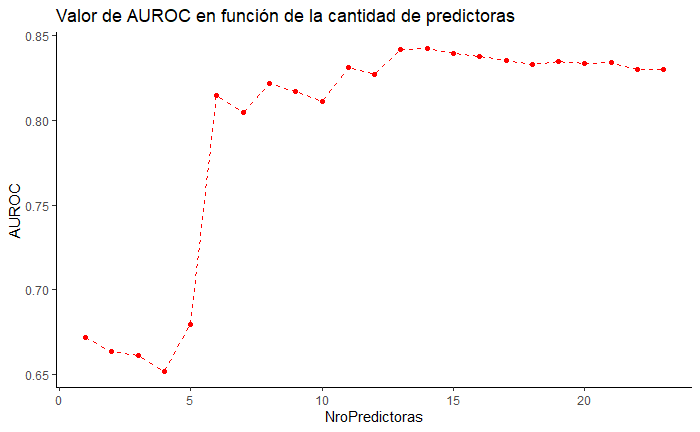

```r
g1 <- df_resumen_resultados %>%
  ggplot(aes(x = NroPredictoras)) +
  geom_point(aes(y = AUROC), size = 1.5, color = "red") +
  geom_line(aes(y = AUROC), linetype = 2, color = "red") +
  ggtitle("Valor de AUROC en función de la cantidad de predictoras") +
  theme_classic()

g2 <- df_resumen_resultados %>%
  ggplot(aes(x = NroPredictoras)) +
  geom_point(aes(y = k), size = 1.5, color = "blue") +
  geom_line(aes(y = k), linetype = 2, color = "blue") +
  ggtitle("Valor de K en función de la cantidad de predictoras") +
  theme_classic()

g1
```

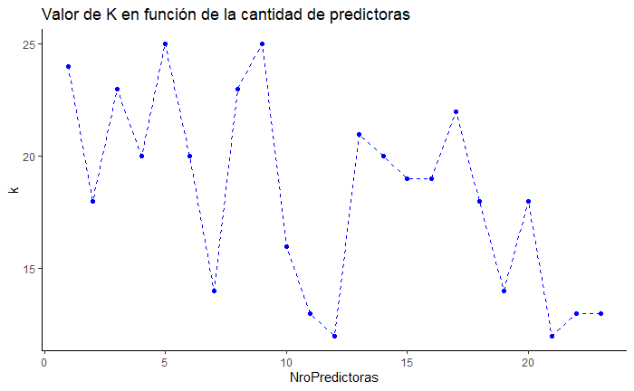

```r
g2
```

```r
NA
```

```r
# Predictoras usados en el modelo con 5 variables
df_resumen_resultados %>% filter(NroPredictoras == 5) %>% select(Predictoras)
```

| Predictoras |
| --- |
| d1 d2 d3 d4 d5 |

```r
# Predictoras usados en el modelo con 6 variables
df_resumen_resultados %>% filter(NroPredictoras == 6) %>% select(Predictoras)
```

| Predictoras |
| --- |
| d1 d2 d3 d4 d5 edad |

La úniva variable que difiere es edad, qué tan bien ayuda a clasificar esta variable por si sola? (Puede darse que esta variable solo sea buena en conjunción con el resto de variables y no por si sola)

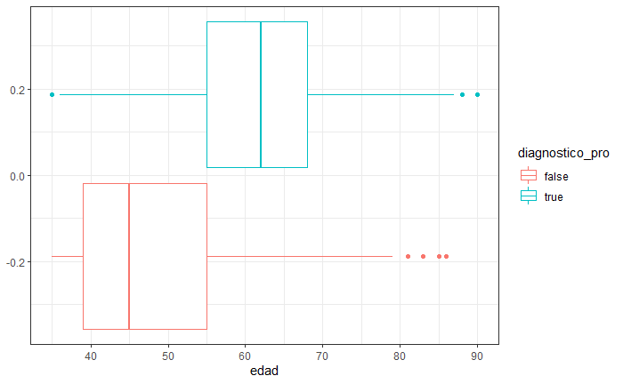

```r
datos %>%
  ggplot(aes(x = edad, color = diagnostico_pro)) +
  geom_boxplot() +
  theme_bw()
```

Probamos dos modelos:

- Teniendo únicamente como predictora a edad.
- Agarrar el modelo con mejor auc y sacar a edad de las predictoras.

Para ambos casos vamos a usar los mismos valores de K y la misma forma de hallar el k

```r
grid_train <- expand.grid(k = seq(K_MIN, K_MAX, AVANCE_k))
train_control <- trainControl(method = METODO_CROSS_VALIDATION, number = K_FOLD)
```

Vamos con el primero.

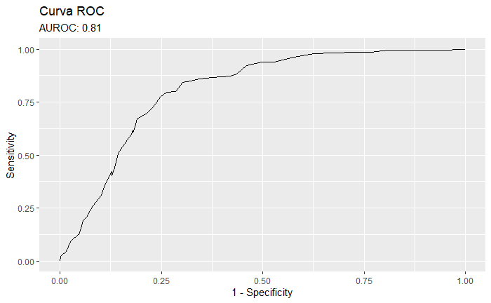

```r
df_knn_edad <- datos %>% select(all_of(c("diagnostico_pro", "edad"))) %>% drop_na()

set.seed(SEED)
indices_train <- createDataPartition(df_knn_edad$diagnostico_pro, p = PORCENTAJE_TRAIN)[[1]]
df_knn_edad_train <- df_knn_edad[indices_train,]
df_knn_edad_test <- df_knn_edad[-indices_train,]

knn_edad <- train(diagnostico_pro ~ .,
                  df_knn_edad_train,
                  method = METODO_KNN,
                  trControl = train_control,
                  tuneGrid = grid_train)

graficar_curva_roc(knn_edad,
                   df_knn_edad_test,
                   nivel_positivo = NOMBRE_NIVEL_POSITIVO_VAR_RESPUESTA,
                   var_respuesta = NOMBRE_VAR_RESPUESTA,
                   type_predict = TYPE_PREDICT_KNN)
```

Vamos con el segundo modelo

```r
(df_resumen_resultados %>% arrange(desc(AUROC)))[1, "Predictoras"]
```

```
[1] "d1 d2 d3 d4 d5 edad educ empleo genero estado_marital facilidad_celular F0semitoneFrom27.5Hz_sma3nz_stddevNorm F0semitoneFrom27.5Hz_sma3nz_amean F0semitoneFrom27.5Hz_sma3nz_percentile20.0"
```

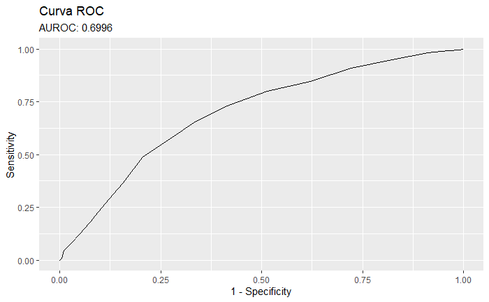

```r
df_knn_sin_edad <- datos %>% select(all_of(c("diagnostico_pro",
                                         "d1",
                                         "d2",
                                         "d3",
                                         "d4",
                                         "d5",
                                         "educ",
                                         "empleo",
                                         "genero",
                                         "estado_marital",
                                         "facilidad_celular",
                                         "F0semitoneFrom27.5Hz_sma3nz_stddevNorm",
                                         "F0semitoneFrom27.5Hz_sma3nz_amean",
                                         "F0semitoneFrom27.5Hz_sma3nz_percentile20.0"))) %>%
  drop_na()

df_y <- df_knn_sin_edad %>% select(diagnostico_pro)
df_x <- df_knn_sin_edad %>% select(-diagnostico_pro)


df_x_normalizado <- df_x %>%
  preProcess(method = PRE_PROCESS_NORMALIZAR) %>%
  predict(df_x) %>%
  data.frame()


df_x_normalizado_dummy <- dummyVars(~., df_x_normalizado) %>%
  predict(df_x_normalizado) %>%
  data.frame()

df <- cbind(df_y, df_x)

set.seed(SEED)
indices_train <- createDataPartition(df$diagnostico_pro, p = PORCENTAJE_TRAIN)[[1]]
df_train <- df[indices_train,]
df_test <- df[-indices_train,]

knn_sin_edad <- train(diagnostico_pro ~ .,
                  df_train,
                  method = METODO_KNN,
                  trControl = train_control,
                  tuneGrid = grid_train)

graficar_curva_roc(knn_sin_edad,
                   df_test,
                   nivel_positivo = NOMBRE_NIVEL_POSITIVO_VAR_RESPUESTA,
                   var_respuesta = NOMBRE_VAR_RESPUESTA,
                   type_predict = TYPE_PREDICT_KNN)
```